# Time dependent predictors and interventions

Source: [`vignettes/interventions.qmd`](https://github.com/cdriveraus/ctsem/blob/master/vignettes/interventions.qmd)

```r
library(ctsem)
library(ggplot2)
```

A time dependent predictor is a variable observed alongside the measurements that acts on the latent processes: a treatment session, a stressful event, a dose of a drug. This vignette shows how ctsem models such inputs, and how to model effects that are immediate, lasting, or that build up and fade.

## Predictors are impulses

A time dependent predictor is a column of the data, named in `ctModel(TDpredNames = )`. At each row, the processes shift by the predictor’s value times its effect in `TDPREDEFFECT`, and the dynamics then carry the shift forward. A predictor of zero has no effect, so an event is coded 1 on the row at which it happens and 0 elsewhere.

On its own, the effect of such an impulse fades at the rate the drift matrix sets for the process. A shock to mood that fades as quickly as mood’s other fluctuations is described well that way. Many interventions are meant to change the level for good, or to have an effect that builds up over some days and then fades. These shapes are modelled with an extra latent process that receives the impulse and passes it on to the outcome through the drift matrix (Driver & Voelkle, 2018, *Understanding the time course of interventions with continuous time dynamic models*).

## Simulated data

One hundred people rate their mood at 25 irregular times over 20 days. Half of them receive a treatment on day 10, coded as `treat = 1` on their first rating from day 10 on. In the generating model the treatment’s effect builds up over a few days and then fades. It acts through an input process that jumps to 1 at the treatment, returns to zero at a rate of 0.5 a day, and raises mood at a rate of 1 a day per unit of input. Mood returns to its own baseline at a rate of 0.3 a day, and each person has their own baseline.

```r
set.seed(2)
design <- do.call(rbind, lapply(1:100, function(i) {
  d <- data.frame(id = i, time = sort(unique(round(runif(25, 0, 20), 2))),
    treat = 0)
  if (i <= 50) d$treat[which(d$time >= 10)[1]] <- 1
  d
}))

gen <- ctModel(type = 'ct', silent = TRUE,
  manifestNames = 'mood', latentNames = c('mood', 'input'),
  TDpredNames = 'treat', LAMBDA = matrix(c(1, 0), 1, 2),
  DRIFT = matrix(c(-0.3, 1,
                    0,  -0.5), 2, 2, byrow = TRUE),
  TDPREDEFFECT = matrix(c(0, 1), 2, 1),
  DIFFUSION = matrix(c(0.5, 0, 0, 0), 2, 2),
  CINT = matrix(0, 2, 1), T0MEANS = matrix(0, 2, 1), T0VAR = diag(c(1, 0)),
  MANIFESTMEANS = matrix('mm|param|TRUE|0.5'), MANIFESTVAR = matrix(0.3))
dat <- data.frame(ctGenerate(gen, datastruct = design, backend = 'julia',
  values = c(mm = 0)))
head(dat[dat$id == 1 & dat$time > 8, ])
```

```
#>    id  time treat       mood
#> 11  1  8.11     0 -0.7161700
#> 12  1  8.90     0 -0.5934409
#> 13  1  9.36     0 -1.1816630
#> 14  1 11.00     1 -0.4093268
#> 15  1 11.05     0  0.2235895
#> 16  1 11.47     0  0.2068280
```

`ctGenerate(datastruct = )` takes the design, here the ids, times and treatment column, and fills in the measurements.

The average mood of the treated and untreated groups, in two-day bins:

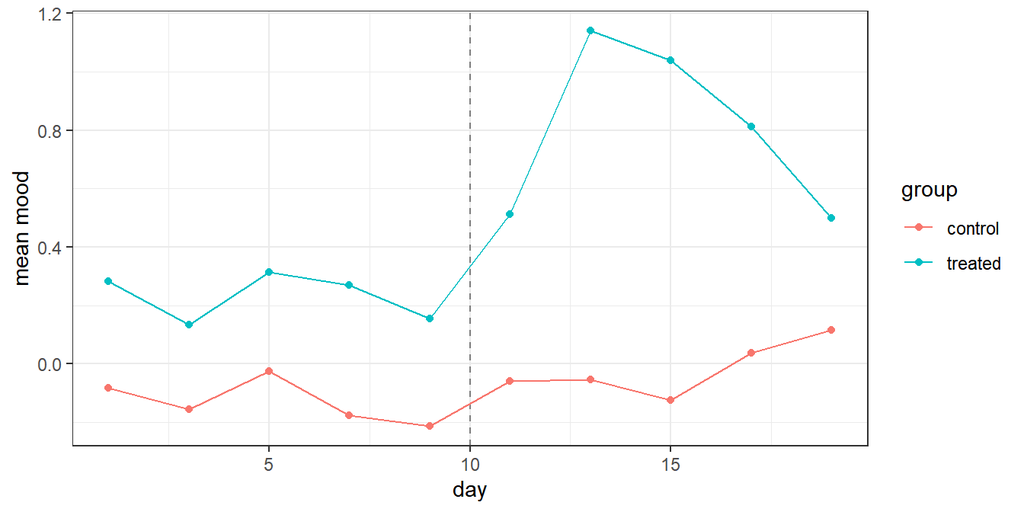

```r
dat$group <- ifelse(dat$id <= 50, 'treated', 'control')
dat$bin <- floor(dat$time / 2) * 2 + 1
means <- aggregate(mood ~ group + bin, data = dat, FUN = mean)
ggplot(means, aes(bin, mood, colour = group)) +
  geom_vline(xintercept = 10, linetype = 'dashed', colour = 'grey50') +
  geom_line() + geom_point() + theme_bw() +
  labs(x = 'day', y = 'mean mood')
```

The groups differ a little before day 10 by chance, through the people’s own baselines. After day 10 the treated group’s mood rises for a few days and then falls back.

## Three models of the treatment effect

**An impulse.** The treatment shifts mood directly, and the shift fades at mood’s own rate:

```r
m_impulse <- ctModel(LAMBDA = matrix(1),
  manifestNames = 'mood', latentNames = 'mood', TDpredNames = 'treat')
```

**A lasting change.** The treatment sets an input process to 1, where it stays, because its auto effect and its shocks are fixed at zero. The input affects mood through the drift matrix (`input_effect`), so mood moves gradually to a new equilibrium. The input’s effect from the treatment is fixed at 1, which sets its scale, and the treatment has no direct effect on mood. The input starts at zero, with no variance.

```r
m_level <- ctModel(LAMBDA = matrix(c(1, 0), 1, 2),
  manifestNames = 'mood', latentNames = c('mood', 'input'),
  TDpredNames = 'treat',
  DRIFT = matrix(c('drift_mood', 'input_effect',
                    0,            0), 2, 2, byrow = TRUE),
  TDPREDEFFECT = matrix(c(0, 1), 2, 1),
  DIFFUSION = matrix(c('diff_mood', 0, 0, 0), 2, 2),
  T0MEANS = matrix(c('T0m_mood', 0), 2, 1),
  T0VAR = matrix(c('T0var_mood', 0, 0, 0), 2, 2))
```

**An effect that builds up and fades.** The same, with the input’s auto effect estimated, so the input returns to zero at an estimated rate:

```r
m_dissipate <- ctModel(LAMBDA = matrix(c(1, 0), 1, 2),
  manifestNames = 'mood', latentNames = c('mood', 'input'),
  TDpredNames = 'treat',
  DRIFT = matrix(c('drift_mood', 'input_effect',
                    0,            'drift_input'), 2, 2, byrow = TRUE),
  TDPREDEFFECT = matrix(c(0, 1), 2, 1),
  DIFFUSION = matrix(c('diff_mood', 0, 0, 0), 2, 2),
  T0MEANS = matrix(c('T0m_mood', 0), 2, 1),
  T0VAR = matrix(c('T0var_mood', 0, 0, 0), 2, 2))
```

`ctModelLatex(m_dissipate)` writes the model as equations. The treatment enters the input process through `TDPREDEFFECT`, and the input reaches mood through the drift matrix:

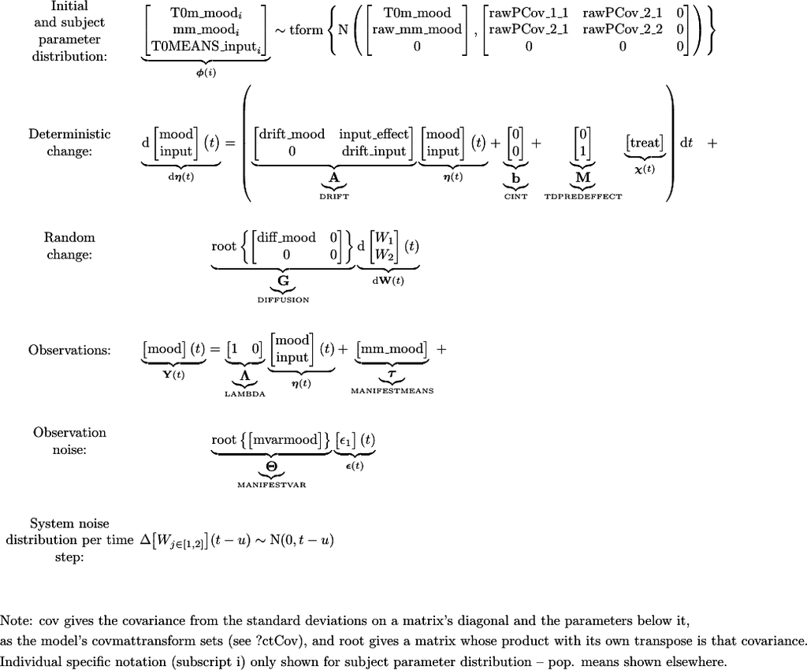

Other shapes follow from the same idea. A direct effect in `TDPREDEFFECT` together with an input process gives an immediate shift plus a lasting change, and an input process with a second input feeding it gives an effect that builds up more slowly.

```r
fits <- list(
  impulse   = ctFit(dat, m_impulse, cores = 2),
  lasting   = ctFit(dat, m_level, cores = 2),
  dissipate = ctFit(dat, m_dissipate, cores = 2))
sapply(fits, function(f) c(logLik = f$estimate$loglik, AIC = summary(f)$aic))
```

```
#>          impulse   lasting dissipate
#> logLik -1990.051 -1959.654 -1922.706
#> AIC     3998.103  3937.308  3865.411
```

The model in which the effect builds up and fades fits best by far. Its estimates, against generating values of -0.3 for `drift_mood`, 1 for `input_effect` and -0.5 for `drift_input`:

```r
summary(fits$dissipate)$popmeans[c('drift_mood', 'input_effect',
  'drift_input'), c('mean', '2.5%', '97.5%')]
```

```
#>                mean   2.5%  97.5%
#> drift_mood   -0.327 -0.406 -0.258
#> input_effect  0.987  0.773  1.192
#> drift_input  -0.366 -0.496 -0.252
```

## The time course of the effect

The expected effect of one treatment on the processes, a time $t$ later, is $e^{At} M$, with $A$ the drift matrix and $M$ the column of `TDPREDEFFECT`. Its first entry is the effect on mood. Computing it for each draw of the parameters gives its uncertainty:

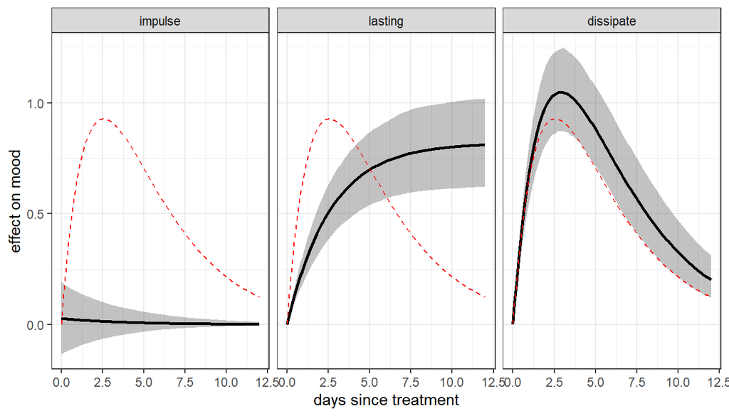

```r
effect_course <- function(fit, times) {
  e <- ctExtract(fit)
  curves <- sapply(seq_len(dim(e$pop_DRIFT)[1]), function(i) {
    A <- matrix(e$pop_DRIFT[i, , ], dim(e$pop_DRIFT)[2])
    M <- e$pop_TDPREDEFFECT[i, , 1]
    sapply(times, function(t) (expm::expm(A * t) %*% M)[1])
  })
  data.frame(time = times, mean = rowMeans(curves),
    lower = apply(curves, 1, quantile, .025),
    upper = apply(curves, 1, quantile, .975))
}
times <- seq(0, 12, by = 0.1)
courses <- do.call(rbind, lapply(names(fits), function(n)
  data.frame(model = n, effect_course(fits[[n]], times))))
courses$model <- factor(courses$model, levels = names(fits))

truth <- data.frame(time = times, mean = sapply(times, function(t)
  (expm::expm(matrix(c(-0.3, 1, 0, -0.5), 2, 2, byrow = TRUE) * t) %*%
    c(0, 1))[1]))

ggplot(courses, aes(time, mean)) +
  geom_ribbon(aes(ymin = lower, ymax = upper), alpha = 0.3) +
  geom_line(linewidth = 1) +
  geom_line(data = truth, linetype = 'dashed', colour = 'red') +
  facet_wrap(~model) + theme_bw() +
  labs(x = 'days since treatment', y = 'effect on mood')
```

Each panel shows a model’s estimated effect with its 95% interval, and the dashed line the effect that generated the data. The impulse model can only describe an effect that is largest at the moment of treatment, and it estimates a small one. The lasting change model fits an effect that builds up and never fades. The third model recovers the shape, an effect that peaks about three days after the treatment and then fades, though it fades a little more slowly than the effect that generated the data.

## Notes

- A predictor’s value at a row acts at that row’s time. For an intervention that runs over a period, such as a course of therapy, either code each session as its own impulse, or switch an input process on and off. In the lasting change model, a second predictor coded 1 at the end of the period, with an effect of -1 on the input, sets the input back to zero.
- The size of the effect can vary between people and depend on covariates, as any parameter can. Writing the input’s effect in the drift matrix as `'input_effect||TRUE'` lets it vary, and `'input_effect, tipreds=c(age)'` lets it depend on age.
- A missing value in a time dependent predictor is replaced by zero, with a warning.